Quickly analyze test market campaigns based on responses, revenue and other key metrics. Predict who will respond to which campaign by which channel and why. Increase the likelihood of responses and quality of leads in future campaigns.

## The description of the data set

All of these variables are beneficial for our modeling process. We will set sales in thousands as our target variable and analyze to see what variables contribute the most to sales.

## Feature engineering

To make our modeling process more efficient, we need to transform the data into appropiate formats. Here we outline some of the transformation steps:

1. Week is now a numeric variable and can be dummied into 4 columns, each column represents one week.
2. Promotion is also a numeric variable and needed to be dummied into columns for each type of promotion.
3. Age of Stores has many numbers and can be grouped into 4 bins, bin 1 contains stores with younger ages and bin 4 contains stores with older ages.

```
# A tibble: 3 x 3
  .metric .estimator .estimate
  <chr>   <chr>          <dbl>
1 rmse    standard      10.4
2 rsq     standard       0.566
3 mae     standard       8.60
```

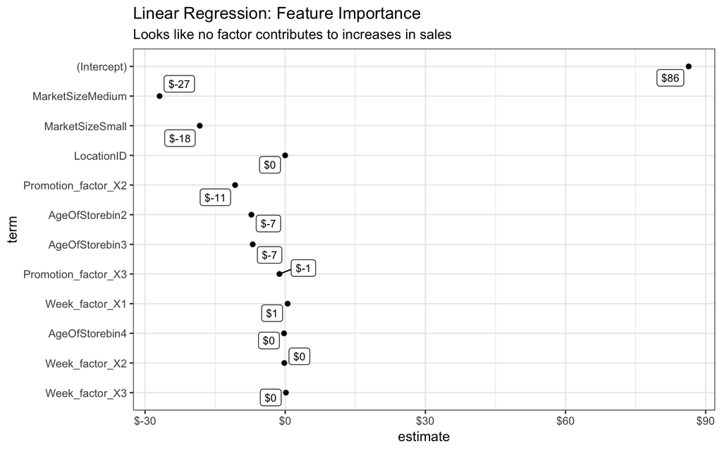

## Conclusion

The model predicts that there is no variables contributing to increases in sales except week 1 with one thousands increase in sales. Other variables such as market size and promotion factors are both not having efficiency in increasing sales but actually decreasing it.

2019-04-05